# Monte Carlo Testing: Additional Examples

## Type 1 Errors and the P-Value Distribution

I want to sample from $N(\mu, 5^2)$

Say I want to test $H_0: \mu = 10$ vs $H_A: \mu > 10$

I can use the test statistic simply being $\bar{X}$. Naturally if $\bar{X}$ is high then I would consider that evidence against $H_0$.

Here’s a function to generate sample data given $\mu$ and a test statistic function.

```r
generate_data <- function(n, mu){
  return(rnorm(n, mu, 5))
}

test_stat <- function(someData){
  return(mean(someData))
}
```

Suppose we want to use a significance level of 7%. Why 7%? Why not!?! Imagine here is some data - note that this data is being generated from an alternative model ($\mu=11$).

```r
set.seed(1)
myData <- rnorm(25, 11, 5)
myData
```

```
##  [1]  7.86773095 11.91821662  6.82185694 18.97640401 12.64753886  6.89765808
##  [7] 13.43714526 14.69162353 13.87890676  9.47305806 18.55890584 12.94921618
## [13]  7.89379710 -0.07349944 16.62465459 10.77533195 10.91904868 15.71918105
## [19] 15.10610598 13.96950661 15.59488686 14.91068150 11.37282492  1.05324152
## [25] 14.09912874
```

Let’s generate a test statistic distribution under the null hypothesis. What are typical values of $\bar{X}$ when the null hypothesis is true? If you remember the central limit theorem it will come as no surprise that this distribution is $N(10, 5^2/25)$

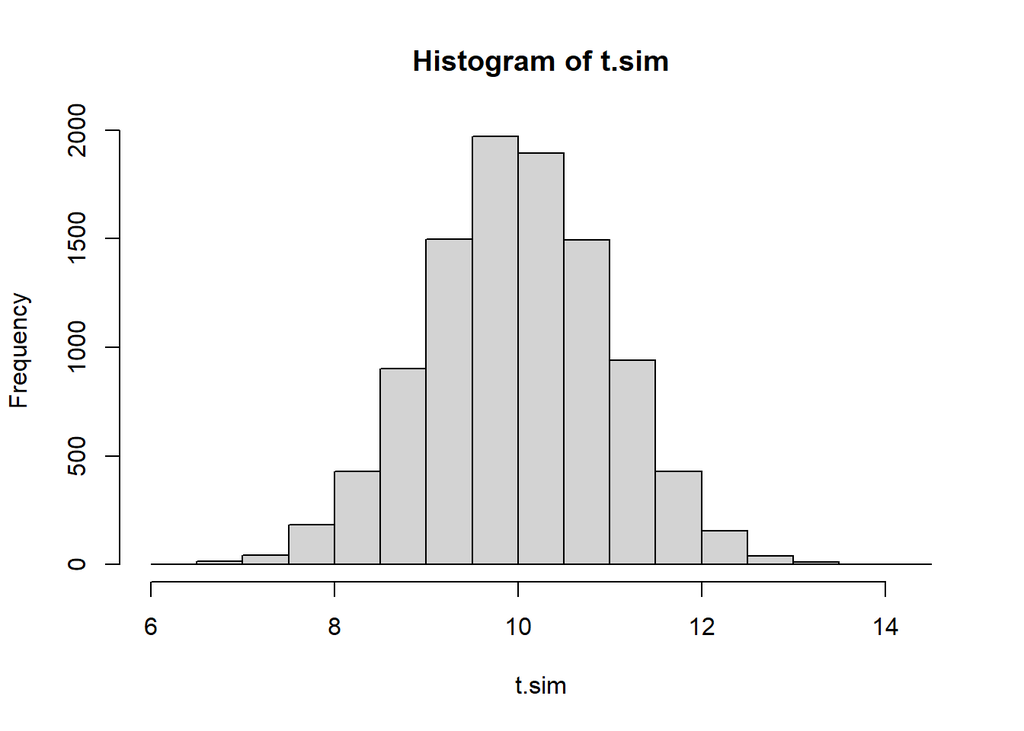

```r
NMC <- 10000
t.sim <- replicate(NMC, test_stat(generate_data(25, 10)))
hist(t.sim)
```

```r
mean(t.sim);var(t.sim)
```

```
## [1] 9.994043
```

```
## [1] 0.9879012
```

We want to pick a rejection threshold (a critical value) $t_\alpha$ designed to achieve a significance level (type 1 error rate) of .07. If $\bar{X} \geq t_\alpha$ we reject $H_0$, and this should occur 7% of the time when $H_0$ is true. Rather than using the theoretical normal distribution for $\bar{X}$, we’ll use the simulated test statistics to approximate the threshold.

```r
t.crit <- quantile(t.sim, .93)
#verify
mean(t.sim >= t.crit)
```

```
## [1] 0.07
```

Let’s just make sure that if the null hypothesis is true that we end up rejecting 7%

```r
result <- FALSE
for(i in 1:NMC){
  nullData <- generate_data(25, 10)
  result[i] <- test_stat(nullData) >= t.crit
  # result will be TRUE if the test stat is beyond the critical
  # value, ie. we reject the null
  #False otherwise
}
mean(result)
```

```
## [1] 0.0732
```

I’m curious about the p-values you get from this test. I mean - if the null hypothesis is true, what p-values would you expect to get? Let’s repeat with the null hypothesis, and just record p-values.

To put it another way - Because $T(D_0)$ is a random variable, $Pr[T(D) > T(d_0)]$ is a random variable as well; the $p$-value under the null hypothesis can be thought of as a random variable and thus it has a distribution. What is the shape of this distribution? Let’s use Monte Carlo to estimate it.

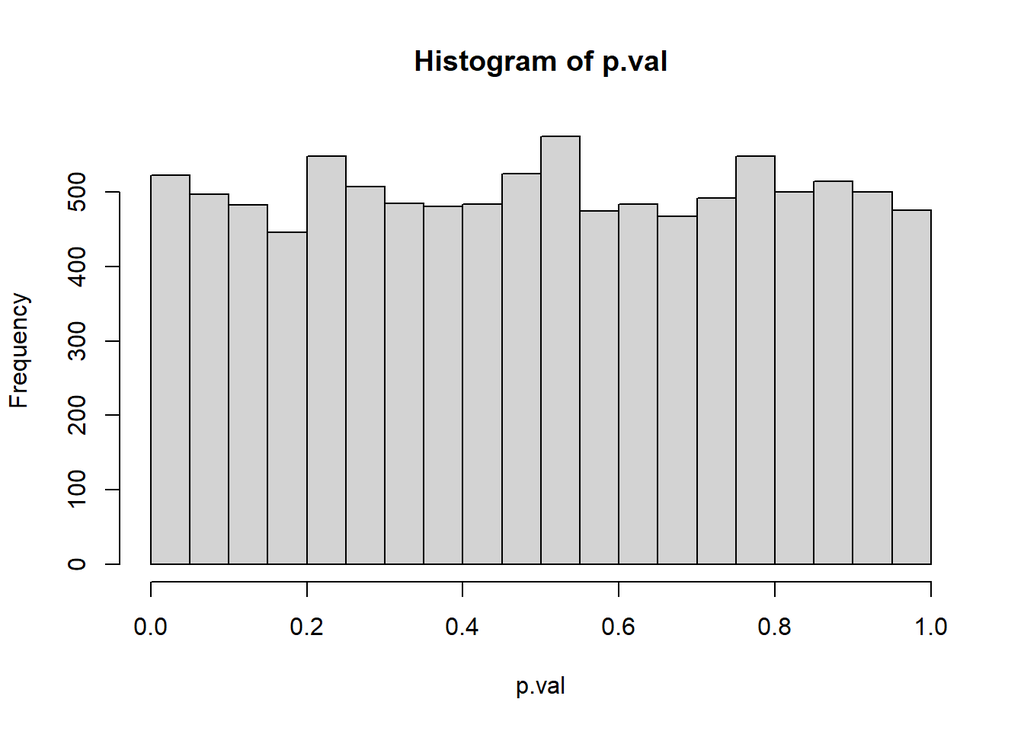

```r
p.val <- 0
for(i in 1:NMC){
  nullData <- generate_data(25, 10)
  p.val[i] <- mean(t.sim >= test_stat(nullData))
}
hist(p.val)
```

If the null hypothesis is true, and we get data and calculate a p-value, the p-value will be uniformly distributed according to a uniform(0,1). This turns out to be the case for ANY hypothesis test. It’s a little less precise when your test statistic is a discrete r.v., but it is more or less going to be the case.

What about the distribution of p-values if the mean = 11 (i.e. the null is false) - this is the model from which we got our initial data.

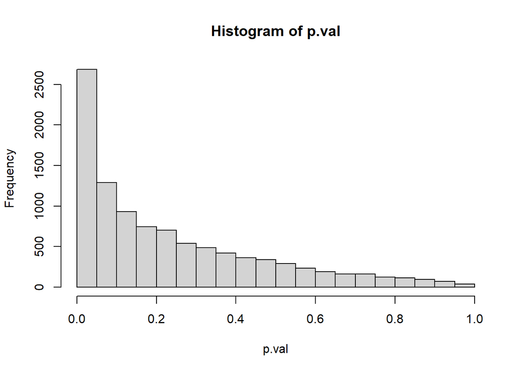

```r
p.val <- 0
for(i in 1:NMC){
  altData <- generate_data(25, 11)
  p.val[i] <- mean(t.sim >= test_stat(altData))
}
hist(p.val)
```

```r
mean(p.val <= 0.07)
```

```
## [1] 0.3277
```

```r
mean(p.val >0.07)
```

```
## [1] 0.6723
```

So it seems if the data was drawn from a normal distribution with a mean of 11, we have a 32.77% probability of getting “strong evidence” to reject H_0. That’s the power of this test.

## Achieving exact alpha with a discrete test statistic distribution

Going back to the example from lecture, suppose we want to achieve an exact type 1 error rate of 2.5%. We’re flipping a coin and we want to know what rejection rule we should use for the lower-bound on the number of heads - to conclude that the coin is not fair.

To remind you - we are flipping a coin 200 times, we have to come up with a rule such that if the flips are producing too low of heads, we reject the null hypothesis (and we would do something similar for the upper tail).

The goal is to find some rejection rule for low X that will reject 2.5% of the time for a fair coin.

```r
#P (X <= 85) for X~Binom(200, .5)
pbinom(85, 200, .5)
```

```
## [1] 0.0200186
```

```r
#P (X <= 86) for X~Binom(200, .5)
pbinom(86, 200, .5)
```

```
## [1] 0.02798287
```

```r
#P(X = 86)
dbinom(86, 200, .5)
```

```
## [1] 0.007964274
```

$$P(X \leq 85) = 0.0200186$$

$$P(X \leq 86) = 0.02798287$$

$$P(X=86) = .00796$$

The idea is we will reject always when X <= 85, sometimes when X = 86, and never when X > 86. What do we want for the sometimes? We want
$$P(X \leq 85) + P(reject \cap X=86) =
0.025$$
In other words:

$$P(reject \cap X=86) = 0.025-P(X \leq
85)$$
Expanding the left hand side

$$P(reject | X=86)\cdot P(X=86) =
0.025-P(X \leq 85)$$
Divide both sides by $P(X=86)$
$$P(reject | X=86) = \dfrac{0.025-P(X \leq
85)}{P(X=86)}$$

```r
#We look at the probability under H0 that we get 86 heads
P.reject.86 <- (.025 - pbinom(85, 200, .5) )/dbinom(86, 200, .5)
P.reject.86
```

```
## [1] 0.6254687
```

So if we get 86 heads, we will reject 62.5% of the time. That’s the idea.

```r
hack_decision_rule <- function(T){
  #T is the number of heads
  if(T <= 85){ return (TRUE)} #always reject if T <= 85
  else if(T==86) {return(rbinom(1, 1, P.reject.86))}
  else {return (FALSE)}
}

#verify that we actually are able to achieve a precise 2.5% type 1 error rate using this "hack" rule.
trials <- rbinom(100000, 200, .5)
reject <- FALSE
for(i in 1:100000){
  reject[i] <- hack_decision_rule(trials[i])
}
mean(reject)
```

```
## [1] 0.02499
```

There are two other ways that we could attempt (that come to my mind) to achieve an exact $\alpha$ with a discrete test statistic distribution.

1. If $X \leq 86$ reject $p$ of the time
2. Always reject 2.5% of the time.

Both of these will attain an $\alpha$ of 0.025, but they are not as powerful (probably). Let’s consider different probabilities from 0 to .5 and compare the powers We’re only refining the rejection rule for the lower tail, so we don’t need to look at the upper tail right now.

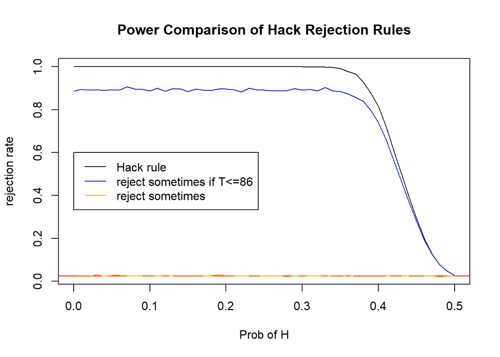

```r
set.seed(1)

rule1.p <- 0.025/pbinom(86,200, .5)

hack_decision_rule1 <- function(T){
  if(T <= 86){
    return(runif(1) < rule1.p)
  } else {
    return(FALSE)
  }
}
hack_decision_rule2 <- function(T){
  return(runif(1) < 0.025)
}


if(file.exists("discrete_exact_alpha.rds")){
  #So this knits faster- load the results if they exist.
  discreteRR <- readRDS("discrete_exact_alpha.rds")
} else {
  pseq <- seq(0,.5,.01)
  rr_0 <- rep(0,length(pseq))
  rr_1 <- rr_0
  rr_2 <- rr_0
  NMC <- 5000
  for(j in 1:length(pseq)){
    p <- pseq[j]
    for(i in 1:NMC){
      #generate data
      nheads <- rbinom(1, 200, p)
      rr_0[j] <- rr_0[j] + hack_decision_rule(nheads)
      rr_1[j] <- rr_1[j] + hack_decision_rule1(nheads)
      rr_2[j] <- rr_2[j] + hack_decision_rule2(nheads)
    }
  }
  rr_0 <- rr_0 / NMC
  rr_1 <- rr_1 / NMC
  rr_2 <- rr_2 / NMC
  discreteRR <- data.frame(pseq, rr_0, rr_1, rr_2)
  saveRDS(discreteRR, "discrete_exact_alpha.rds")
}

plot(rr_0~pseq, type="l", ylab="rejection rate", xlab="Prob of H", main="Power Comparison of Hack Rejection Rules", data=discreteRR)
abline(h=0.025, col="red")
lines(x=discreteRR$pseq, y=discreteRR$rr_1, col="blue")
lines(x=discreteRR$pseq, y=discreteRR$rr_2, col="orange")
legend(x=0, y=.6, legend=c("Hack rule", "reject sometimes if T<=86", "reject sometimes"), col=c("black","blue","orange"), lwd=1)
```

Compare their levels:

```r
rr_0[51]
```

```
## [1] 0.0256
```

```r
rr_1[51]
```

```
## [1] 0.0252
```

```r
rr_2[51]
```

```
## [1] 0.0262
```

## Example: Comparing Consistency

Student A and Student B are in the same class. We are curious to know about their academic performance, in particular their consistency in grade performance.

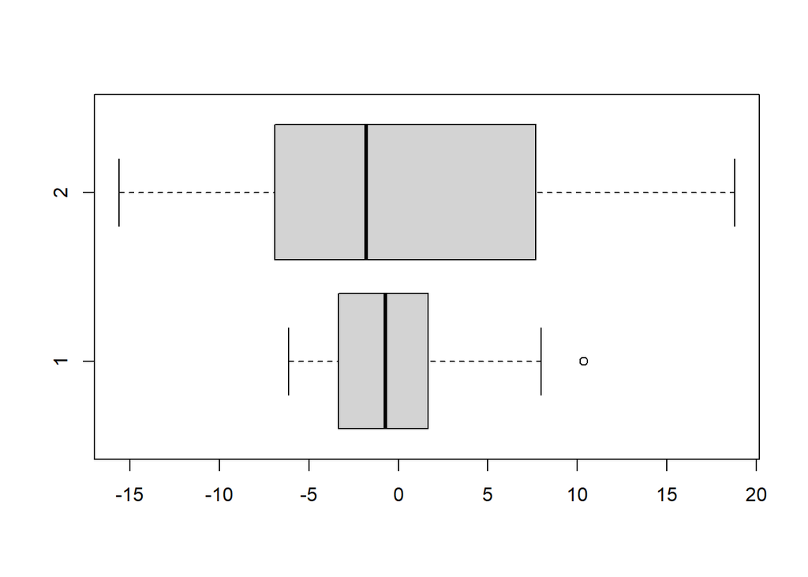

```r
A.grades <- c(83.4,91.4,83.0,77.2,81.9,76.8,82.4,89.0,82.0,74.9,77.6,78.7,79.1,77.8,80.3)
B.grades <- c(75.9,66.4,98.1,83.0,72.4,70.6,67.1,73.0,89.1,87.0,83.9,63.7,88.6,90.0,75.5,86.5,77.5)
A.grades <- A.grades - mean(A.grades)
B.grades <- B.grades - mean(B.grades)
boxplot(A.grades, B.grades, horizontal=TRUE)
```

The question is this: are the two students equally consistent in their grades? Let’s think about consistency in terms of variance

Let’s fill in the following code:

```r
#Takes in two data vectors, compares them in a meaningful way and returns a statistic that is useful to compare consistency.
testStat <- function(dataA, dataB){
  return(var(dataA)-var(dataB))
}

#This function takes in two vector, combines them, shuffles,
#And splits them
#Then calculates a test statistic
permuteAndCompute <- function(dataA, dataB){
  combinedData <- c(dataA, dataB)
  shuffledData<- sample(combinedData)
  simA <- shuffledData[1:length(dataA)]
  simB <- shuffledData[-(1:length(dataA))] #I use negative index
  return(testStat(simA, simB))
}

#Takes in the two data sets and a number of monte carlo runs. It will perform the MC simulation NMC times and it will return a distribution of test statistics.
mcDist <- function(dataA, dataB, MNC){
  results <- 0
  for(i in 1:NMC){
    results[i] <- permuteAndCompute(dataA, dataB)
  }
  return(results)
}
```

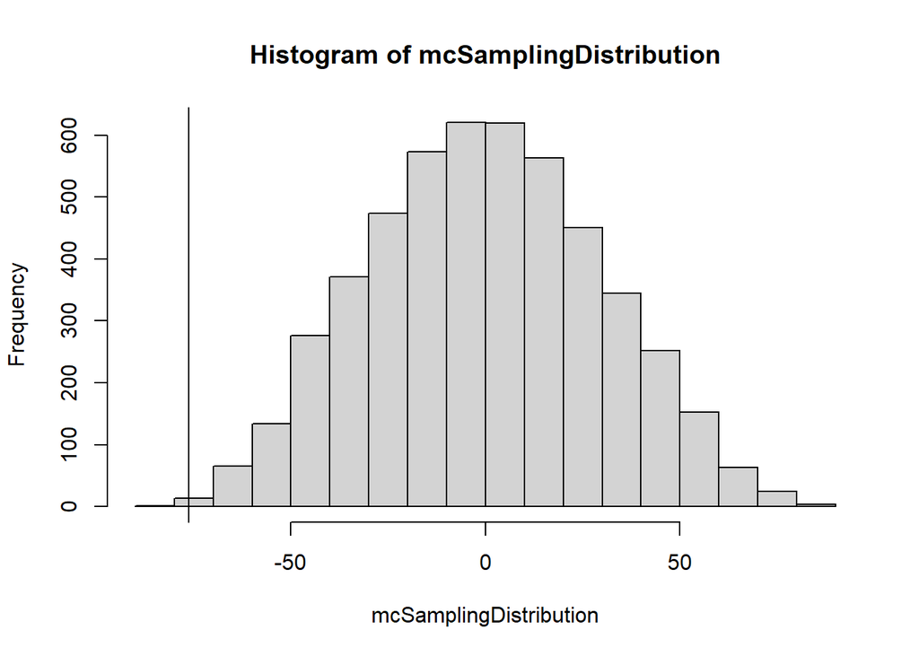

```r
obsTestStat <- testStat(A.grades, B.grades)
mcSamplingDistribution <- mcDist(A.grades, B.grades, 10000)

hist(mcSamplingDistribution)
abline(v=obsTestStat)
```

```r
obsTestStat
```

```
## [1] -76.26533
```

```r
mean(mcSamplingDistribution >= obsTestStat)
```

```
## [1] 0.9992
```

```r
mean(mcSamplingDistribution <= obsTestStat)
```

```
## [1] 8e-04
```

We have about .1% in the left-tail, more extreme than our observed test statitic. However the question we were investigating is “Are they equally consistent or not”

So - if the test statisitc was very positive (+75 or so) we would also consider that evidence for the alternative.

This is a two-sided test; we need to calculate probability from both sides of the distribution. What we want to do then is to follow this model:

1. calculate the probability <= obs. test stat
2. calculate the probability >= obs. test stat
3. take the smaller of the two
4. Double it

```r
#This is my formula for a 2-tailed p-value
2*min(mean(mcSamplingDistribution>=obsTestStat),
      mean(mcSamplingDistribution<=obsTestStat))
```

```
## [1] 0.0016
```

If this was a symmetric distribution, this would be the same as:

```r
mean(mcSamplingDistribution>= abs(obsTestStat)) + mean(mcSamplingDistribution<= -abs(obsTestStat))
```

```
## [1] 0.002
```

Let’s suppose we used some other measure of “difference of consistency” For example, we could take the ratio of the variances.

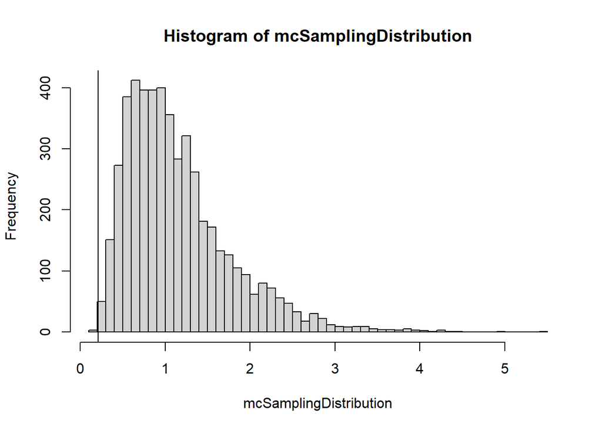

```r
#redefine the test statistic
testStat <- function(dataA, dataB){
  return(var(dataA)/var(dataB))
}

obsTestStat <- testStat(A.grades, B.grades)
mcSamplingDistribution <- mcDist(A.grades, B.grades, 10000)

hist(mcSamplingDistribution, breaks=50)
abline(v=obsTestStat)
```

```r
2*min(mean(mcSamplingDistribution >= obsTestStat),
      mean(mcSamplingDistribution <= obsTestStat))
```

```
## [1] 0.002
```